# ScRNAseq_training

Xiao Xiao

2021/6/10

## ScRNAseq data analysis training

Using Dr. Ha’s data, here we will show how to do ScRNAseq data analysis with seurat package:

```r
Sys.setenv(lang="en")   #change error massage into English
setwd("D:/training/scRNAseq")

# 0) Load necessary packages
#install.packages('Seurat')
#install.packages("Matrix", repos="http://R-Forge.R-project.org")
library(Seurat)
library(dplyr)
library(Matrix)
```

```r
library(cowplot)
library(openxlsx)
library(ggplot2)
```

## 1) Read in matrix files

Get the barcodes, matrix, and features file from the cell ranger. Then put them together in a folder.

```r
matrix_dir <- "E:/coding materials/single cell RNA sequencing/210114"
pbmc.data<-Read10X(data.dir = matrix_dir)
```

### 1.1) If you want, you can take a look at the expression data

```r
exprs <- as.matrix(pbmc.data)
```

## 2) Quality control (filter)

### 2.1) Filter cells that has less than 200 gene expression values, and genes that are expressed in less than 3 cells

```r
pbmc <- CreateSeuratObject(counts = pbmc.data, project = "pbmc3k", min.cells = 3, min.features = 200)
```

## 2.2) Filter cells that exhibit aberrantly high gene counts and cells that exhibit extensive mitochondrial contamination (dying cells)

### Mark all the mitochondrial genes

```r
pbmc[["percent.mt"]] <- PercentageFeatureSet(pbmc, pattern = "^MT-")
```

### Draw a violin plot to determine the filtering threshold

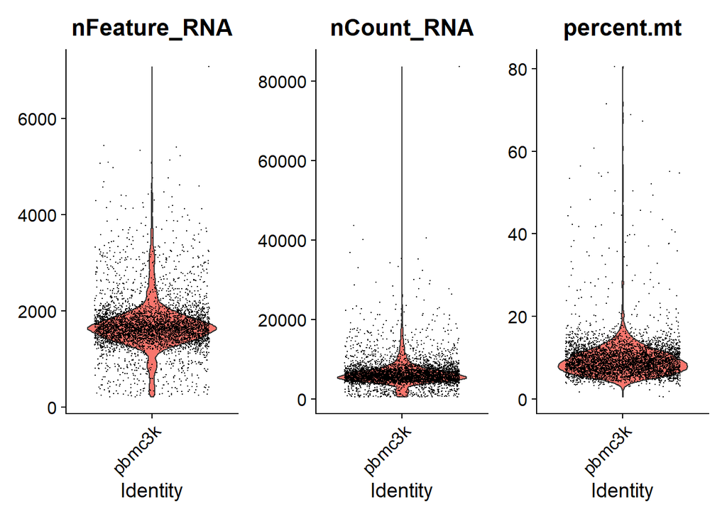

```r
VlnPlot(pbmc, features = c("nFeature_RNA", "nCount_RNA", "percent.mt"), ncol = 3)
```

### Apply the filtering threshold

```r
pbmc <- subset(pbmc, subset = nFeature_RNA > 200 & nFeature_RNA < 6000 & percent.mt < 20)
```

## 2.3) If you want, you can take a look at the expression

```r
exprs2<-as.matrix(pbmc@assays$RNA@data)
```

## 3) Normalize the data

### 3.1) For each cell, the feature counts are divided by total counts and multiplied by scale.factor. Then the counts are log transformed.

### To take a look at total gene counts before normalization. count_sum_before<-1:4400; for (i in 1:4400) {count_sum_before[i]<-sum(exprs2[,i])}; plot(1:4400,count_sum_before)

```r
pbmc <- NormalizeData(pbmc, normalization.method = "LogNormalize", scale.factor = 10000)
```

### To take a look at total gene counts after normalization. count_sum_after<-1:4400; exprs3<-as.matrix(pbmc@assays$RNA@data); for (i in 1:4400) {count_sum_after[i]<-sum(exprs3[,i])}; plot(1:4400,count_sum_after)

### 3.2) Before clustering, find the 2000 most variable genes used for clustering

```r
pbmc <- FindVariableFeatures(pbmc, selection.method = "vst", nfeatures = 2000)
```

### 3.3) Scale data. This is a standard preprocessing step before PCA. It shifts the expression of each gene, so that the mean expression across cells is 0 - Scales the expression of each gene, so that the variance across cells is 1.

```r
all.genes <- rownames(pbmc)
pbmc <- ScaleData(pbmc, features = all.genes)
```

## 4) Clustering

### 4.1) Run PCA to reduce the 2000 dimentions to around 10. Here we can only use PCA to reduce dimentions for clustering in seurat.

```r
set.seed(123)
pbmc_2000 <- RunPCA(pbmc, features = VariableFeatures(object = pbmc))
```

```
## PC_ 1
## Positive:  LTB, IL32, IL7R, CCR7, KLF2, PRKCQ-AS1, SELL, NELL2, TSHZ2, AQP3
##     ITM2A, CD27, PASK, RORA, CD69, HSP90AB1, DNAJB1, ADTRP, NOG, SESN3
##     NGFRAP1, CMSS1, ISG20, CD8B, HSPB1, EPHB6, GATA3, CCL5, HSPE1, DUT
## Negative:  LYZ, CLEC7A, VCAN, SERPINA1, CSTA, S100A9, S100A8, CD14, CD300E, CYBB
##     C15orf48, SPI1, MPEG1, RP11-1143G9.4, TGFBI, PLAUR, SEMA6B, THBS1, TYMP, CD68
##     ANPEP, NAMPT, IL8, CST3, CXCL16, TIMP1, NCF2, PLXDC2, KLF10, IFI30
## PC_ 2
## Positive:  LTB, CCR7, PABPC1, CD79A, SELL, IL7R, MS4A1, TSHZ2, TSC22D3, SPINT2
##     LINC00926, ACTN1, HLA-DQB1, BANK1, CTSH, CD27, CD40, MYC, PRKCQ-AS1, SESN3
##     HLA-DQA2, HLA-DRA, TSPAN33, PASK, NELL2, NAP1L1, TNFRSF13C, ARHGAP24, CTA-250D10.23, ICOSLG
## Negative:  NKG7, CST7, GNLY, FGFBP2, GZMB, CCL5, PRF1, GZMA, CTSW, APMAP
##     EFHD2, GZMH, KLRD1, MATK, C1orf21, CLIC3, KLRB1, APOBEC3G, GPR56, MIR142
##     SPON2, ITGB2, MYO1F, KLRF1, AOAH, METRNL, HOPX, IL2RB, PRSS23, SH2D1B
## PC_ 3
## Positive:  TMSB10, LAPTM5, PABPC1, CD44, VIM, KLF6, NFKBIA, HSP90AA1, JUN, TXNIP
##     MT-ND1, HSP90AB1, JUNB, ZFP36L1, EIF4A1, EIF1, NEAT1, KLF2, ARL4C, SUB1
##     IRF1, LTB, ARPC3, S100A10, CALR, SEC61B, CD74, DAZAP2, TNFAIP3, S100A6
## Negative:  SDPR, PF4, NRGN, TUBB1, GNG11, PPBP, CLU, ACRBP, SPARC, TREML1
##     CMTM5, ITGA2B, HIST1H2AC, RGS18, MAP3K7CL, GP9, MYL9, TMEM40, PGRMC1, PRKAR2B
##     ESAM, MMD, CTTN, AC147651.3, PTGS1, PTCRA, SMOX, MARCH2, RUFY1, MTURN
## PC_ 4
## Positive:  IL7R, VIM, S100A10, IL32, PRKCQ-AS1, PABPC1, AQP3, NELL2, TSHZ2, ACTN1
##     SELL, RGCC, LTB, DNAJB1, CD27, S100A11, CTSL, SAMHD1, CCR7, ADTRP
##     NGFRAP1, NOG, ARL4C, SOCS3, MT1X, AIF1, CD44, PASK, CD4, TNFAIP8
## Negative:  CD79A, MS4A1, HLA-DQA2, CD74, CD79B, LINC00926, HLA-DQB1, HLA-DRB5, ADAM28, HLA-DRB1
##     CD40, BANK1, HLA-DPB1, TCF4, HLA-DPA1, CHPT1, TSPAN33, HLA-DRA, COBLL1, ARHGAP24
##     IGLL5, HLA-DQA1, CTA-250D10.23, BLK, TNFRSF13C, CD83, CTSH, HLA-DMB, KIAA0226L, IRF8
## PC_ 5
## Positive:  PPP1R14B, CXCR3, GZMK, FAM129A, LYAR, GAPDH, DUSP4, FTH1, CD44, SLC7A5
##     CD82, PERP, NXPH4, TNFAIP3, ITM2C, RORA, APOBEC3G, MIAT, PHACTR2, JUN
##     DFNB31, ST8SIA1, KLF6, MT-ND1, ANXA1, RBPJ, CD84, KLRG1, VIM, S100A11
## Negative:  SH2D1B, CD38, SPON2, PLAC8, TMSB10, IGFBP7, TYROBP, ITGB2, PRSS23, GPR56
##     FCGR3A, PRF1, SELL, TTC38, ACTN1, KLRF1, CCR7, GZMB, FCER1G, KRT86
##     LAT2, RAMP1, RHOBTB3, AOAH, KRT81, FGFBP2, IFITM3, NOG, TXNIP, CTSD
```

## 4.2) Clustering via k-nearest-neighbor algorithm, using the first 10 PCA dimentions

### In this step, the smaller the k and the larger the resolution, the more clusters we will get.

```r
pbmc_2000_k15 <- FindNeighbors(pbmc_2000, k.param = 15, dims = 1:10)
pbmc_2000_k15_r1 <- FindClusters(pbmc_2000_k15, resolution = 1.0)
```

```
## Modularity Optimizer version 1.3.0 by Ludo Waltman and Nees Jan van Eck
##
## Number of nodes: 4400
## Number of edges: 141276
##
## Running Louvain algorithm...
## Maximum modularity in 10 random starts: 0.8365
## Number of communities: 13
## Elapsed time: 0 seconds
```

## 4.3) Run umap for visualization

```r
pbmc_2000_k15_r1_umap <- RunUMAP(pbmc_2000_k15_r1, dims = 1:10)
```

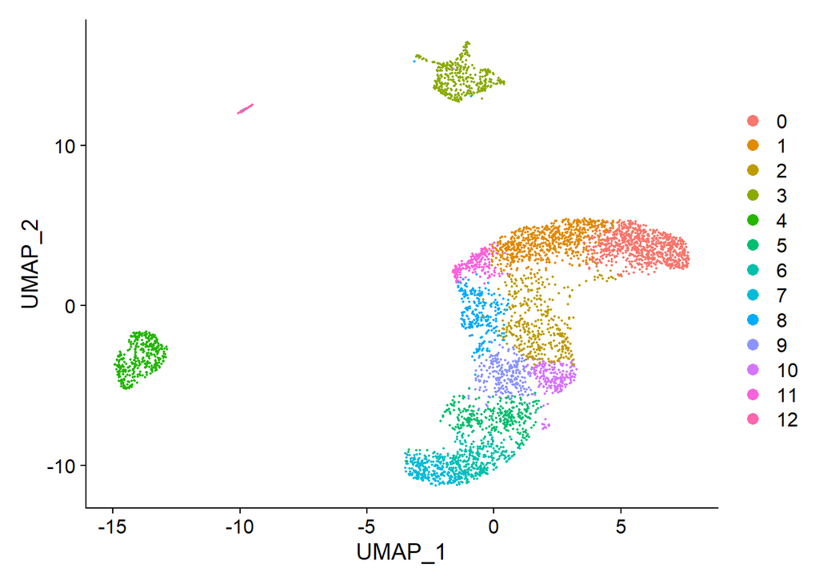

```r
DimPlot(pbmc_2000_k15_r1_umap, reduction = "umap")
```

## 4.4) Decide markers for certain cell types

```r
markers.to.plot <- c("CD3D","CD4","CTLA4","IL7R","CCR7","S100A4","CD14","LYZ","CD19","MS4A1","CD79A","CD79B","BLNK","CD8A","GZMB","CD8B","FCGR3A","MS4A7","NCAM1","KLRB1","KLRC1","KLRD1","KLRF1","GNLY","NKG7","IL3RA","CLEC4C","NRP1","FCER1A","CST3","PPBP")
```

## 4.5) Draw a dot plot to assign clusters

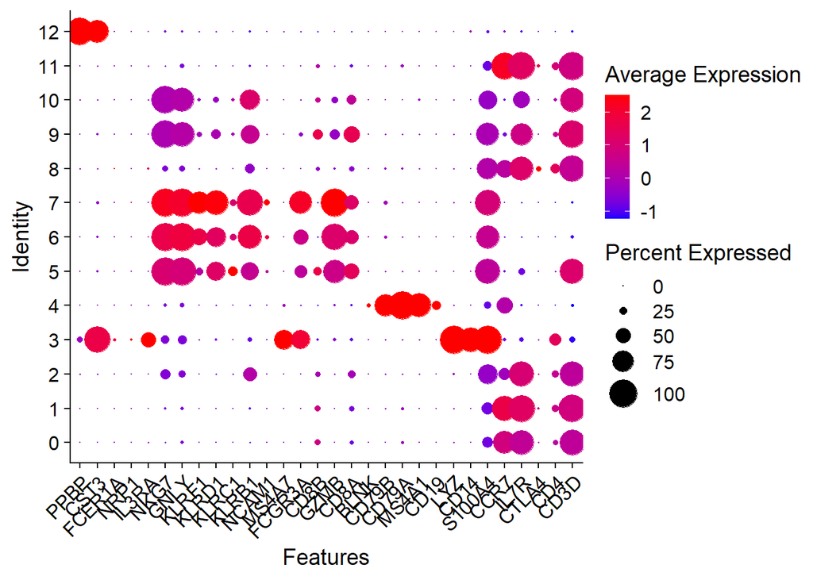

```r
DotPlot(object = pbmc_2000_k15_r1_umap, features = rev(x = markers.to.plot), cols = c("blue", "red"),dot.scale = 8) + RotatedAxis()
```

## 4.6) Input your assignment results

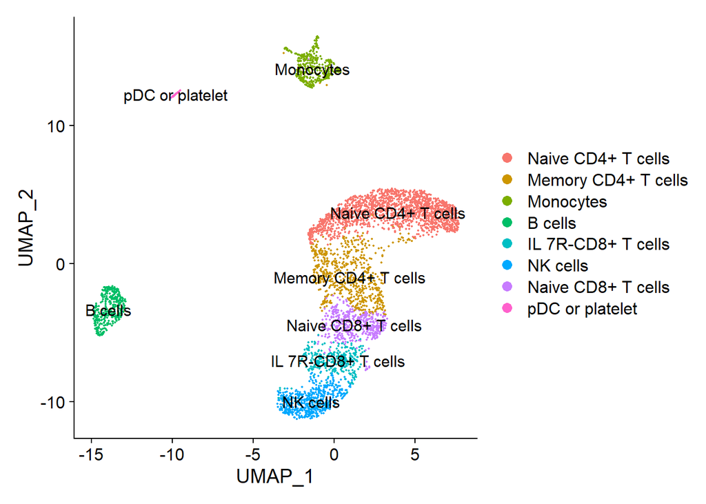

```r
pbmc_2000_k15_r1_umap_labelled <- RenameIdents(pbmc_2000_k15_r1_umap, `0` = "Naive CD4+ T cells", `1` = "Naive CD4+ T cells", `2` = "Memory CD4+ T cells", `3` = "Monocytes", `4` = "B cells", `5` = "IL 7R-CD8+ T cells", `6` ="NK cells" , `7` ="NK cells" , `8` = "Memory CD4+ T cells", `9` = "Naive CD8+ T cells", `10` = "Naive CD8+ T cells", `11` = "Naive CD4+ T cells", `12` = "pDC or platelet")
# 4.7) Draw the plot again
DimPlot(pbmc_2000_k15_r1_umap_labelled, label = TRUE)
```

## 4.8) We can check certain cell marker expression

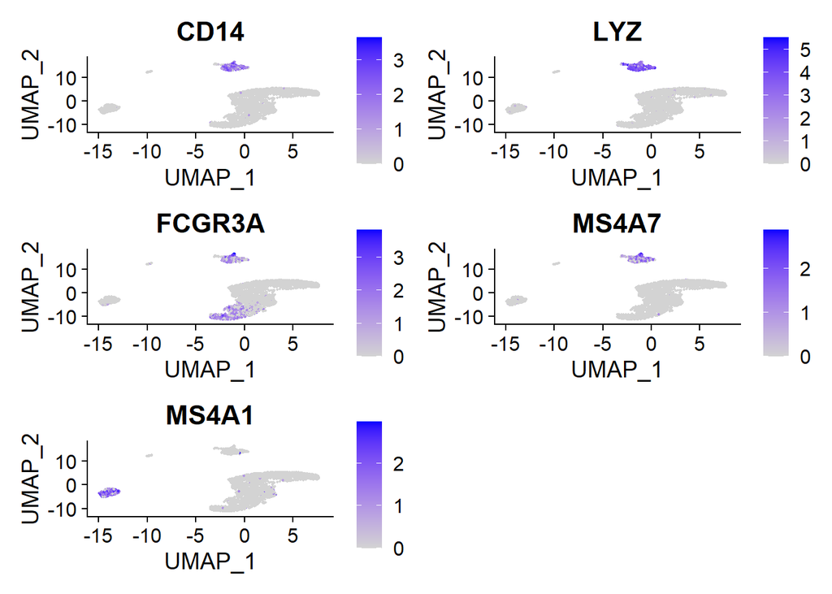

```r
FeaturePlot(pbmc_2000_k15_r1_umap_labelled, features = c("CD14", "LYZ", "FCGR3A", "MS4A7", "MS4A1"))
```

## 4.9) Input the cellular assignment results into the data, for later DEG analysis

```r
pbmc_2000_k15_r1_umap_labelled@meta.data[,6]<-data.frame(pbmc_2000_k15_r1_umap_labelled@active.ident)
```

## 4.10) Get the cell population

### Extract metadata

```r
metadata<-pbmc_2000_k15_r1_umap_labelled@meta.data
```

### Get cell population for control&treat. In this case we know the first 2325 cells are control sample so I just directly write the corresponding code. If in another case the cell number is not 2325, the code will need to be modified accordingly.

```r
cell_pop<-data.frame(table(metadata[1:2325,6]),table(metadata[2326:4507,6]))
```

### Delete one extra column and rename the columns

```r
cell_pop<-cell_pop[,-3]
colnames(cell_pop)<-c("cell_type","cell_number_control","cell_number_test")
```

### write the cell population into excel file

```r
write.xlsx(cell_pop,"cell_pop.xlsx",colnames=TRUE)
```

## 5) DEG analysis

## 5.1) Choose the cell type you wish to analysis. Here we use B cells as an example

```r
B_cells<- subset(pbmc_2000_k15_r1_umap_labelled,subset=seurat_clusters=="B cells")
```

## 5.2) Separate control sample and treatment sample

```r
cellID<-colnames(B_cells@assays$RNA@counts)
sampleID <- as.factor(gsub(".*-","",cellID))
B_cells[["sampleID"]] <- sampleID
B_cells <- SetIdent(object = B_cells, value = "sampleID")
```

## 5.3) Find the DEG using DESeq2 method. Here ident.1 is control sample, ident.2 is treatment sample

```r
deg_B <- FindMarkers(B_cells, ident.1 = 1, ident.2 = 2, logfc.threshold=0.2, min.pct = 0.05, test.use = "DESeq2")
```

## 5.4) Write the DEG results into excel file

```r
write.xlsx(deg_B,"DEG_B.xlsx",row.names=TRUE,colnames=TRUE)
```

## 5.5) Plot heatmap (Here we plot the top 20 DEGs for B cells)

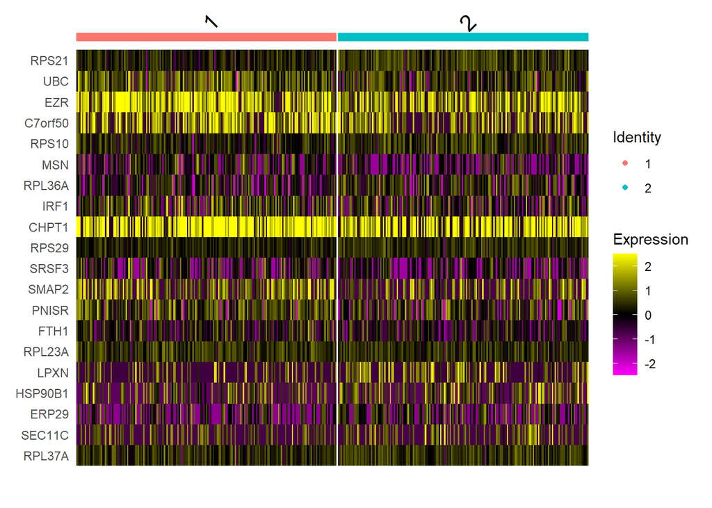

```r
DoHeatmap(B_cells,features = row.names(deg_B)[1:20],group.by = "ident")
```